# IODS course project

herttale

# Week 1

## About the project

This is my first week learning R and R markdown on IODS course. For the next weeks I’ll be publishing my completed exercises here.

Here’s a link to my published GitHub page/course diary: https://herttale.github.io/IODS-project/

And here’s to my GitHub repository: https://github.com/herttale/IODS-project

Enjoy!

# Week 2: Data wrangling and regression analysis

*This week I’ve learned how to modify a dataset for analysis purposes, how to produce different summaries for a dataset and how to study the validity of a linear model. In the following I’ll present the week’s exercises and the methods I used for linear regression analysis and model validation.*

Let’s first read the dataset to the r environment, study it’s structure and dimensions and print a generic summary:

```r
lrn14 <- read.table("data/learn2014Data")
str(lrn14)
```

```
## 'data.frame':    166 obs. of  7 variables:
##  $ gender  : Factor w/ 2 levels "F","M": 1 2 1 2 2 1 2 1 2 1 ...
##  $ Age     : int  53 55 49 53 49 38 50 37 37 42 ...
##  $ Attitude: int  37 31 25 35 37 38 35 29 38 21 ...
##  $ deep    : num  3.58 2.92 3.5 3.5 3.67 ...
##  $ stra    : num  3.38 2.75 3.62 3.12 3.62 ...
##  $ surf    : num  2.58 3.17 2.25 2.25 2.83 ...
##  $ Points  : int  25 12 24 10 22 21 21 31 24 26 ...
```

```r
dim(lrn14)
```

```
## [1] 166   7
```

```r
summary(lrn14)
```

```
##  gender       Age           Attitude          deep            stra
##  F:110   Min.   :17.00   Min.   :14.00   Min.   :1.583   Min.   :1.250
##  M: 56   1st Qu.:21.00   1st Qu.:26.00   1st Qu.:3.333   1st Qu.:2.625
##          Median :22.00   Median :32.00   Median :3.667   Median :3.188
##          Mean   :25.51   Mean   :31.43   Mean   :3.680   Mean   :3.121
##          3rd Qu.:27.00   3rd Qu.:37.00   3rd Qu.:4.083   3rd Qu.:3.625
##          Max.   :55.00   Max.   :50.00   Max.   :4.917   Max.   :5.000
##       surf           Points
##  Min.   :1.583   Min.   : 7.00
##  1st Qu.:2.417   1st Qu.:19.00
##  Median :2.833   Median :23.00
##  Mean   :2.787   Mean   :22.72
##  3rd Qu.:3.167   3rd Qu.:27.75
##  Max.   :4.333   Max.   :33.00
```

As we can see, the dataset consist of 166 rows/observations and 7 columns/variables. The data is based on a survey study done by Kimmo Vehkalahti. The survey was aimed at students and consisted of questions related to learning approaches and students achievements in an introductory statistics course in Univ. of Helsinki. Next I’m going to take a look into the relatinships between the variables of the data.

Variables deep, stra and surf are calculated as means of questions related to deep approach, strategic approach and surface approach to learning. Variable “Attitude” stands for student’s attitude towards statistics and “Points” stands for the student’s final grade.

As we can see from the summary of the data (above), the dataset is skewed in terms of gender - there’s twice as much female students as there is male students. Not suprisingly, the the majority of answers are from students under 30 years old.

Let’s plot the variables in a matrix to study their relationships:

```r
library(GGally)
```

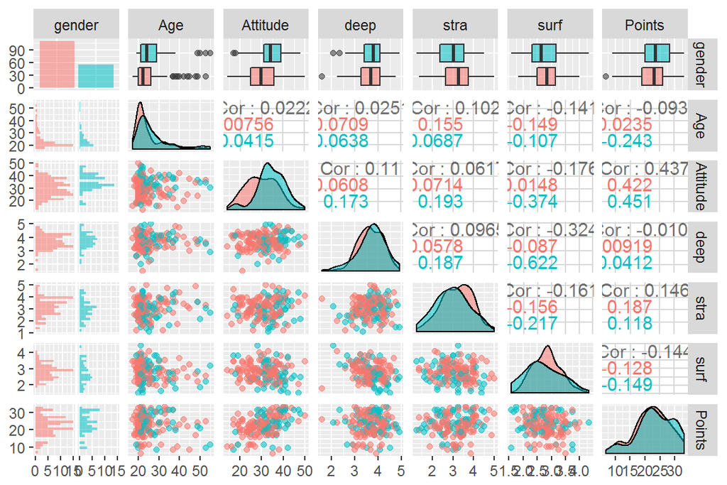

```r
library(ggplot2)
ggpairs(lrn14, mapping = aes(col=gender, alpha = 0.3), lower = list(combo = wrap("facethist", bins = 20)))
```

From the diagram above we can conclude that male students have slightly better attitude towards statistics than female students and female students seem to be slightly more strategic learners than their male peers, but generally the distributions look quite similar for both genders. Overall the correlations between variables are not very high.

Let’s test how attitude and deep and strategic learning are related to students’ points through summarising a linear model:

```r
summary(lm(data = lrn14, Points ~ Attitude + stra + deep))
```

```
##
## Call:
## lm(formula = Points ~ Attitude + stra + deep, data = lrn14)
##
## Residuals:
##      Min       1Q   Median       3Q      Max
## -17.5239  -3.4276   0.5474   3.8220  11.5112
##
## Coefficients:
##             Estimate Std. Error t value Pr(>|t|)
## (Intercept) 11.39145    3.40775   3.343  0.00103 **
## Attitude     0.35254    0.05683   6.203 4.44e-09 ***
## stra         0.96208    0.53668   1.793  0.07489 .
## deep        -0.74920    0.75066  -0.998  0.31974
## ---
## Signif. codes:  0 '***' 0.001 '**' 0.01 '*' 0.05 '.' 0.1 ' ' 1
##
## Residual standard error: 5.289 on 162 degrees of freedom
## Multiple R-squared:  0.2097, Adjusted R-squared:  0.195
## F-statistic: 14.33 on 3 and 162 DF,  p-value: 2.521e-08
```

Here we see that attitude and strategic learning are positively correlated with points, but suprisingly deep learning seems to have a negative relationship with points gained.

We also see that Attitude is the only variable with a statistically significant correlation with points (p-value = 0.00000000444). This means that the propability for getting a sample like this from a population with no correlation between attitude and points is only 0.00000000444 (highly impropable). This means that we can assume with confidence that our sample is somewhat representative of the phenomenon and that there is a significant relationship between attitude and points in our dataset. We are also able to say that strategic and deep learning approaches don’t have a significant correlation and should be removed from the model.

Let’s draw a scatter diagram of only points and attitude:

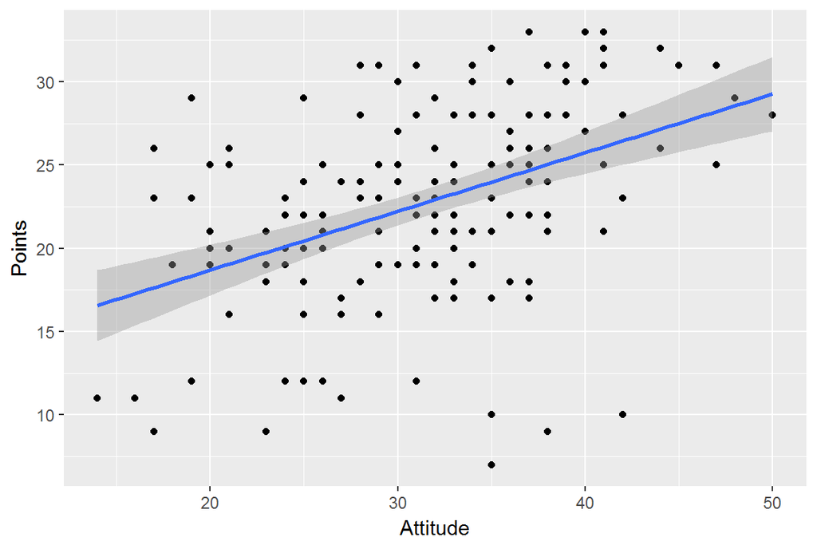

```r
f <- ggplot(data = lrn14, aes(x = Attitude, y = Points))
f + geom_point() + geom_smooth(method = "lm")
```

Lets make a new model with only Points and Attitude:

```r
A_vs_P <- lm(data = lrn14, Points ~ Attitude)
summary(A_vs_P)
```

```
##
## Call:
## lm(formula = Points ~ Attitude, data = lrn14)
##
## Residuals:
##      Min       1Q   Median       3Q      Max
## -16.9763  -3.2119   0.4339   4.1534  10.6645
##
## Coefficients:
##             Estimate Std. Error t value Pr(>|t|)
## (Intercept) 11.63715    1.83035   6.358 1.95e-09 ***
## Attitude     0.35255    0.05674   6.214 4.12e-09 ***
## ---
## Signif. codes:  0 '***' 0.001 '**' 0.01 '*' 0.05 '.' 0.1 ' ' 1
##
## Residual standard error: 5.32 on 164 degrees of freedom
## Multiple R-squared:  0.1906, Adjusted R-squared:  0.1856
## F-statistic: 38.61 on 1 and 164 DF,  p-value: 4.119e-09
```

Here we see that the multiple R-squared is 0.19, which means that with a students’ attitudes we can explain 19 % of their exam points.

When choosing a linear model we assume, that the relationship between our variables is linear and that the residuals of our model are normally distributed. Let’s test our model assumptions by plotting the residuals:

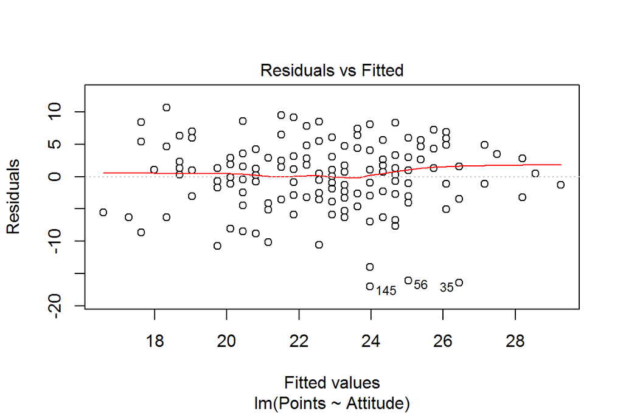

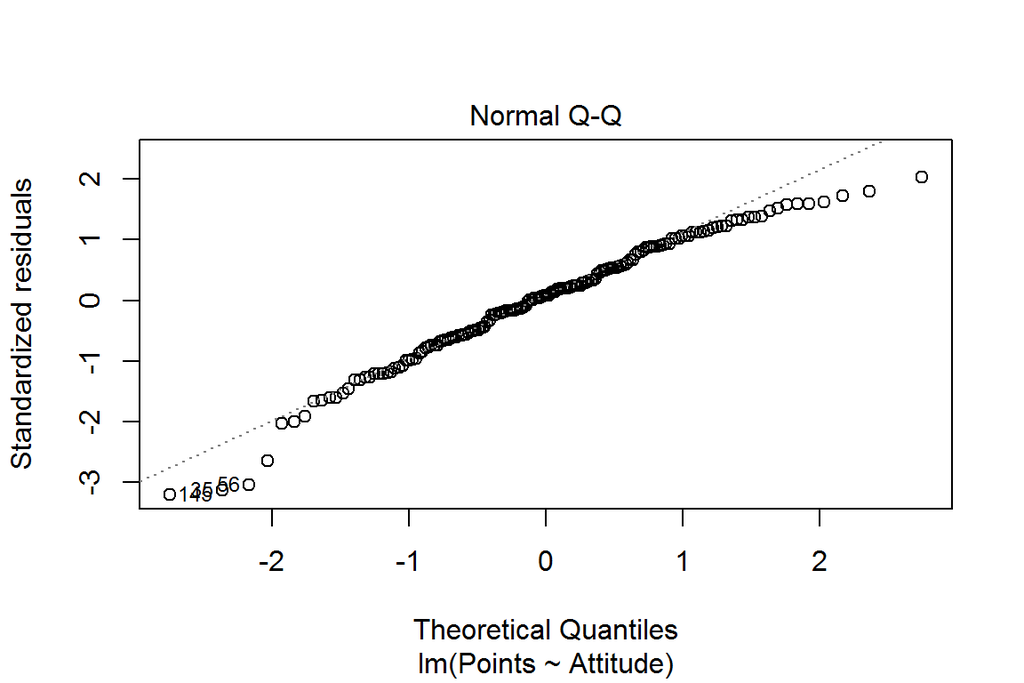

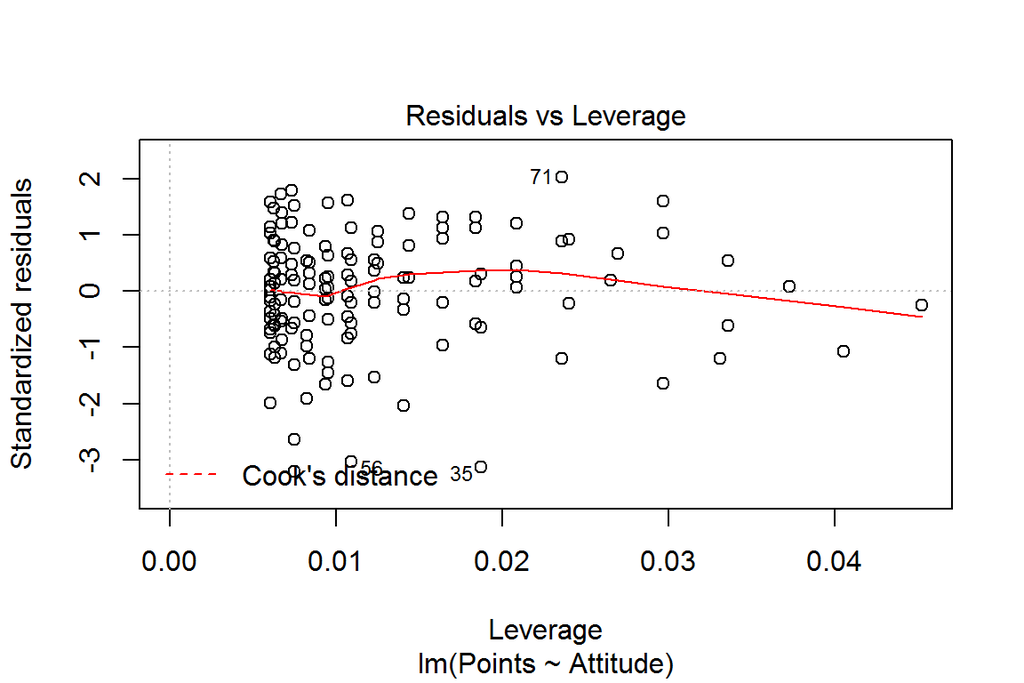

```r
plot(A_vs_P, which = c(1,2,5))
```

From the first plot (Residuals vs Fitted) we can see, that the residuals are quite evenly distributed - there doesn’t seem to be any pattern in the distribution of residuals. This strengthens our assumption of the relationship’s linearity.

The second plot (Normal Q-Q) lets us validate distribution of residuals even better: our model’s residuals are shared in percentiles and plotted against theoretical percentiles of normally distributed data. From the plot we can see that the residuals of our model are approximately normally distributed.

The third plot (Residuals vs Leverage) lets us see if any outliers influence the regression line significantly. If some points are outside the Cook’s distance lines, they are influential for the model. Here we can’t even see Cook’s distance lines, since all observations fit well inside them.

As a conclusion we can state that the linear model fits our data well.

# Week 3

## Logistic regression

**This week i’ve learned some more data wrangling and a new method, logistic regression.**

This week I’ll study the relationship between student’s alcohol consumption and school performance. I’ll explore a dataset with answers from 382 students regarding school attendance/performance, social background and alcohol consumption habits etc. The data’s been derived from https://archive.ics.uci.edu/ml/datasets/STUDENT+ALCOHOL+CONSUMPTION and as stated, it includes alcohol usage, social, gender and study time attributes for each student.

Let’s first read the modified dataset into a data frame and take a look at the columns:

```r
alc <- read.table("data/students_alc")

colnames(alc)
```

```
##  [1] "school"     "sex"        "age"        "address"    "famsize"
##  [6] "Pstatus"    "Medu"       "Fedu"       "Mjob"       "Fjob"
## [11] "reason"     "nursery"    "internet"   "guardian"   "traveltime"
## [16] "studytime"  "failures"   "schoolsup"  "famsup"     "paid"
## [21] "activities" "higher"     "romantic"   "famrel"     "freetime"
## [26] "goout"      "Dalc"       "Walc"       "health"     "absences"
## [31] "G1"         "G2"         "G3"         "alc_use"    "high_use"
```

The data consists of 35 columns/variables: student’s school, student’s sex, student’s age, home address, family size, parent’s cohabitation status mother’s and father’s education, mother’s and father’s job, reason to choose this school, student’s guardian, home to school travel time, weekly study time, number of past class failures, extra educational support, family educational support, extra paid classes within the course subject (Math or Portuguese), extra-curricular activities, attended nursery school, wants to take higher education, Internet access at home, with a romantic relationship, quality of family relationships, free time after school, going out with friends, workday alcohol consumption, weekend alcohol consumption, current health status and number of school absences.

My hypothesis is, that high alcohol consumption is positively correlated with variables goout (going out with friends) and absences (number of school absences) and negatively correlated with romantic (with a romantic relationship) and paid (extra paid classes within the course subject).

Let’s observe the distributions of the variables first with just a set of simple histograms:

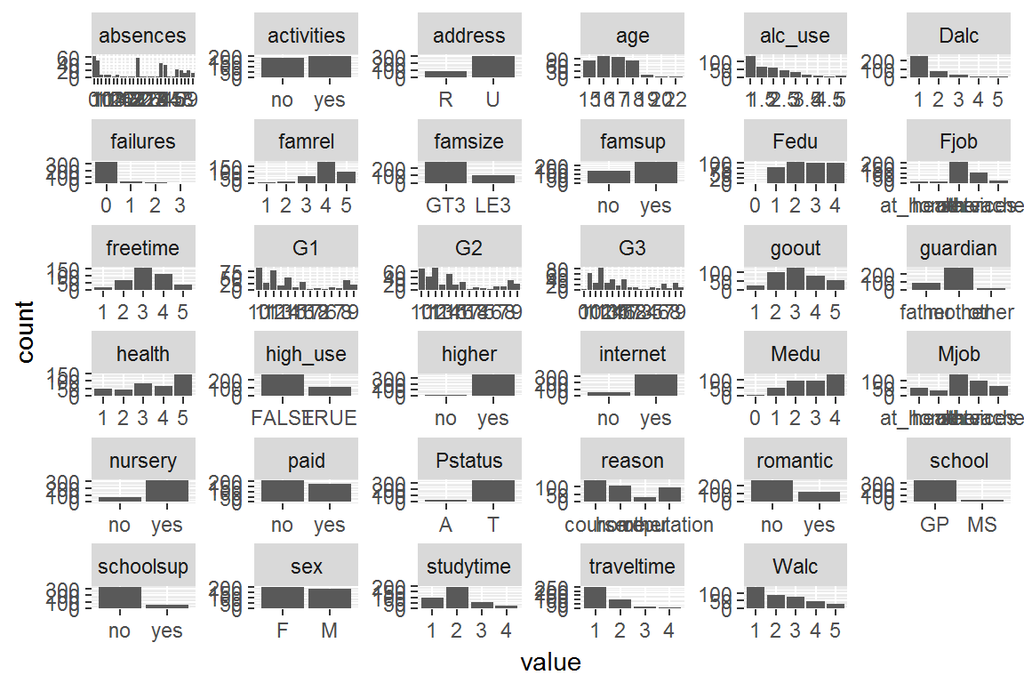

```r
library(tidyr); library(dplyr); library(ggplot2)
gather(alc) %>% ggplot(aes(value)) + facet_wrap("key", scales = "free") + geom_bar()
```

Let’s produce also a numerical summary of some of the variables that interest us:

```r
alc %>% group_by(high_use, paid) %>% summarise(count = n(), mean(absences))
```

```
## Source: local data frame [4 x 4]
## Groups: high_use [?]
##
##   high_use   paid count `mean(absences)`
##      <lgl> <fctr> <int>            <dbl>
## 1    FALSE     no   148         4.168919
## 2    FALSE    yes   120         3.133333
## 3     TRUE     no    57         6.175439
## 4     TRUE    yes    57         6.561404
```

```r
alc %>% group_by(high_use, romantic) %>% summarise(count = n())
```

```
## Source: local data frame [4 x 3]
## Groups: high_use [?]
##
##   high_use romantic count
##      <lgl>   <fctr> <int>
## 1    FALSE       no   180
## 2    FALSE      yes    88
## 3     TRUE       no    81
## 4     TRUE      yes    33
```

Here we see, that students who don’t use much alcohol but take paid classes have less absences in average than their peers who don’t use much alcohol and don’t take paid classes. But suprisingly those students who are heavy alcohol users and take paid extra classes have more absences in average than their peers who are also heavy alcohol users but don’t take paid classes. Overall we can see, that heavy alcohol consumption seems to be related to more school absences.

We also see, that of students who take paid classes 57/(120+57) or 32 % are heavy alcohol users and of students who don’t take paid classes 57/(57+148) or 28 % are heavy alcohol users. This reveals that in the light of this data my hypothesis about a negative relationsip between alcohol usage and paid courses taken is wrong.

Of the students who have a romantic relationship 33/(33+88) or 27 % are heavy alcohol users and of the students who don’t have a romantic relationship 81/(81+180) or 31 % are heavy alcohol users, so there doesn’t seem to be any significant relatioship either.

Let’s make another plot:

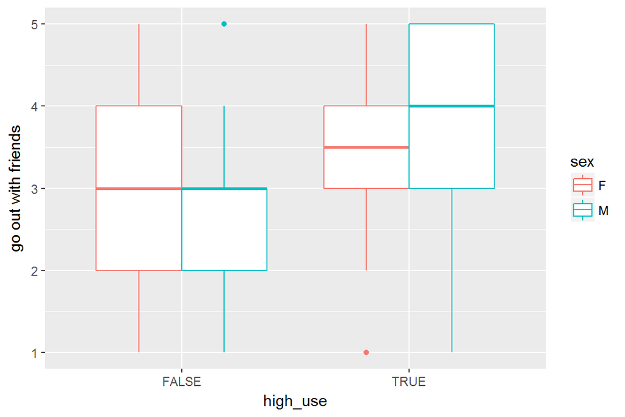

```r
g2 <- ggplot(alc, aes(x = high_use, y = goout, col=sex))

# define the plot as a boxplot and draw it

g2 + geom_boxplot() + ylab("go out with friends")
```

In this boxplot we see, that people with high alcohol usage go out with friends more than their peers with low alcohol usage ON AVERAGE, which lets us assume that our hypothesis of the positive relatioship between these two variables holds.

Let’s try a logistic regression model for our variables:

```r
m <- glm(high_use ~ goout + absences + romantic + paid, data = alc, family = "binomial")

summary(m)
```

```
##
## Call:
## glm(formula = high_use ~ goout + absences + romantic + paid,
##     family = "binomial", data = alc)
##
## Deviance Residuals:
##     Min       1Q   Median       3Q      Max
## -2.0674  -0.7579  -0.5580   0.8997   2.4036
##
## Coefficients:
##             Estimate Std. Error z value Pr(>|z|)
## (Intercept) -3.73867    0.46426  -8.053 8.08e-16 ***
## goout        0.74362    0.11783   6.311 2.77e-10 ***
## absences     0.08181    0.02235   3.660 0.000252 ***
## romanticyes -0.34219    0.27145  -1.261 0.207459
## paidyes      0.31412    0.24716   1.271 0.203760
## ---
## Signif. codes:  0 '***' 0.001 '**' 0.01 '*' 0.05 '.' 0.1 ' ' 1
##
## (Dispersion parameter for binomial family taken to be 1)
##
##     Null deviance: 465.68  on 381  degrees of freedom
## Residual deviance: 399.30  on 377  degrees of freedom
## AIC: 409.3
##
## Number of Fisher Scoring iterations: 4
```

Here we see that only variables “goout” and “absences” have statistically significant relationsips with high alcohol usage. Goout has a very strong positive relationship with high alcohol usage, whereas the absences variable has a very low correlation with high alcohol usage. Let’s remove the statistically insignificant variables from the model, and print a new summary and coefficient’s odds ratios:

```r
m <- glm(high_use ~ goout + absences, data = alc, family = "binomial")

summary(m)
```

```
##
## Call:
## glm(formula = high_use ~ goout + absences, family = "binomial",
##     data = alc)
##
## Deviance Residuals:
##     Min       1Q   Median       3Q      Max
## -1.9111  -0.7480  -0.5173   0.9427   2.3741
##
## Coefficients:
##             Estimate Std. Error z value Pr(>|z|)
## (Intercept) -3.64647    0.43400  -8.402  < 2e-16 ***
## goout        0.73590    0.11715   6.282 3.35e-10 ***
## absences     0.07703    0.02209   3.487 0.000489 ***
## ---
## Signif. codes:  0 '***' 0.001 '**' 0.01 '*' 0.05 '.' 0.1 ' ' 1
##
## (Dispersion parameter for binomial family taken to be 1)
##
##     Null deviance: 465.68  on 381  degrees of freedom
## Residual deviance: 402.50  on 379  degrees of freedom
## AIC: 408.5
##
## Number of Fisher Scoring iterations: 4
```

```r
OR <- coef(m) %>% exp

CI <- confint(m) %>% exp
cbind(OR, CI)
```

```
##                   OR      2.5 %     97.5 %
## (Intercept) 0.026083 0.01076768 0.05922061
## goout       2.087359 1.66817170 2.64318173
## absences    1.080069 1.03581041 1.13071158
```